# exercise1

PengSining

2025-10-30

## 1.R包安装方式

回顾R包的几种不同安装方式

利用 install.packages(“Rcmdr”) 命令安装Rcmdr包

```r
install.packages("Rcmdr", repos = "https://cloud.r-project.org")
```

再用命令load(“Rcmdr”)加载程序包Rcmdr【注：调用程序包应使用library()，调用数据文件可用load()】

```r
library(Rcmdr)
```

请用命令或菜单的方法安装并加载animation程序包,尝试如下两个例子

buffon.needle(nmax = 500, interval = 0)

f <- function(n) rchisq(n, 5);clt.ani(FUN = f)

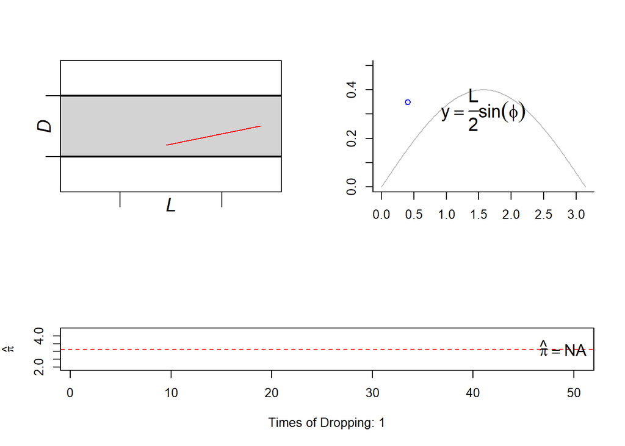

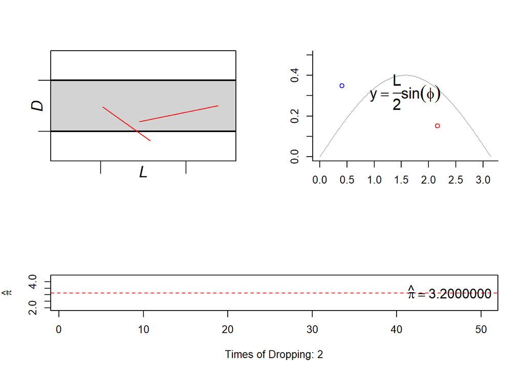

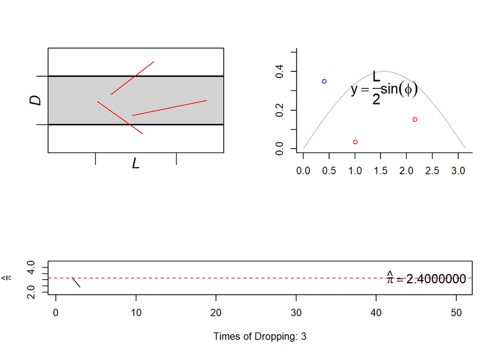

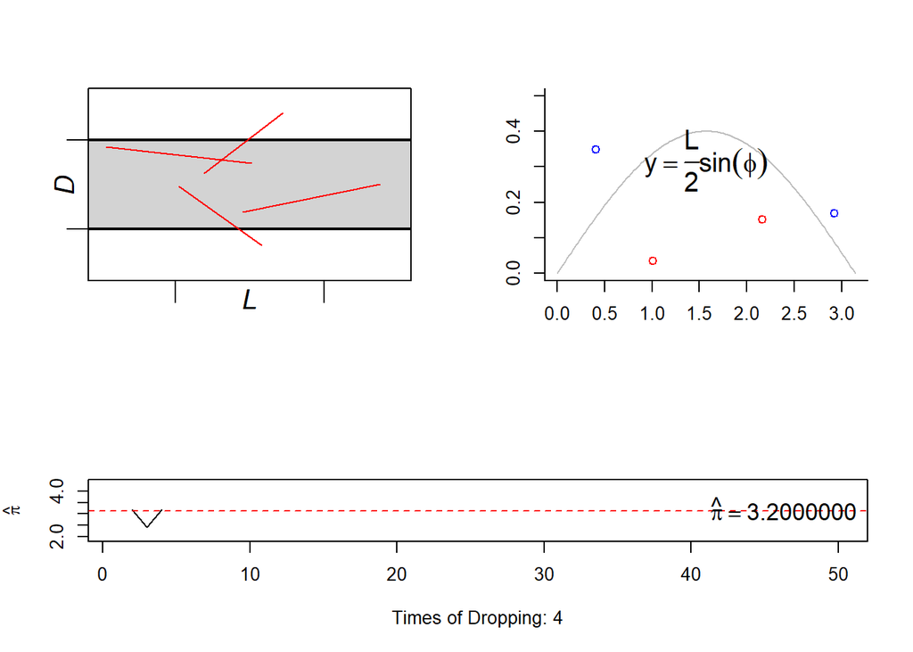

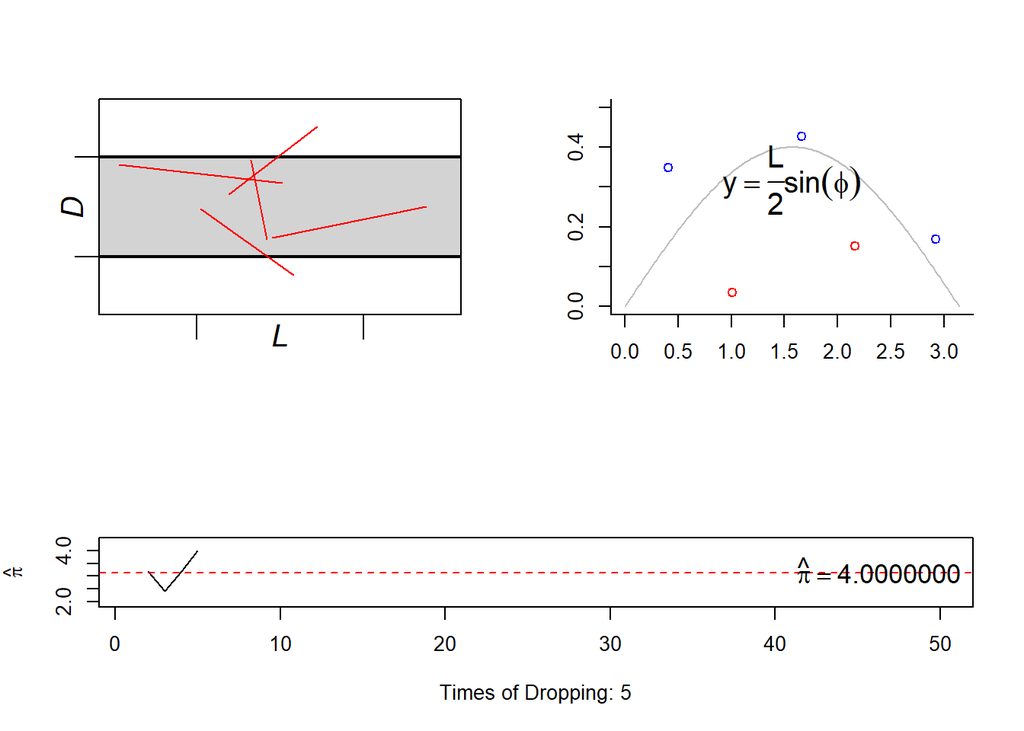

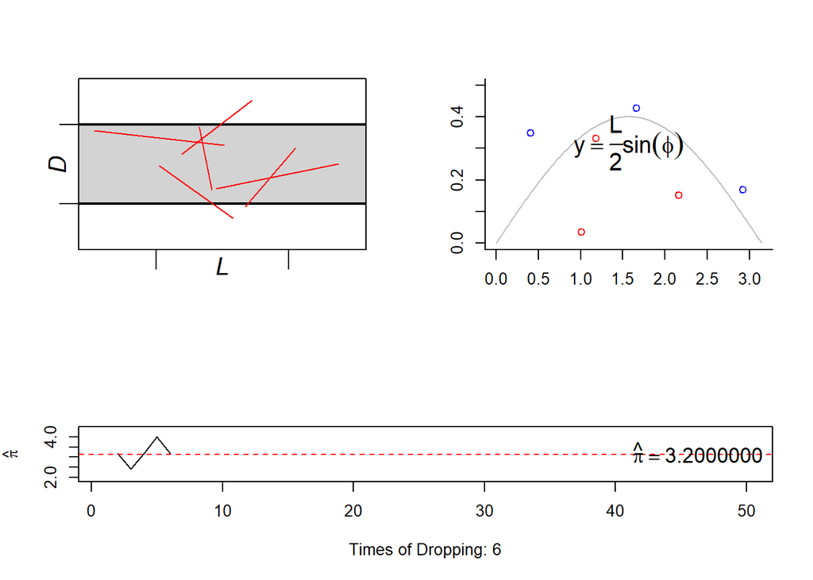

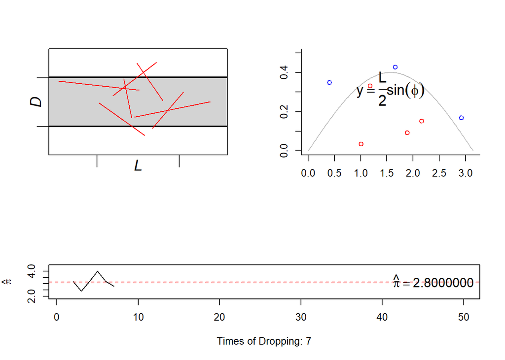

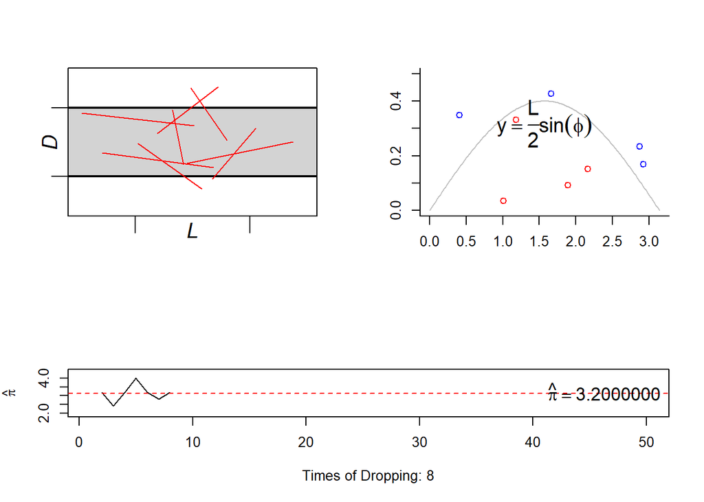

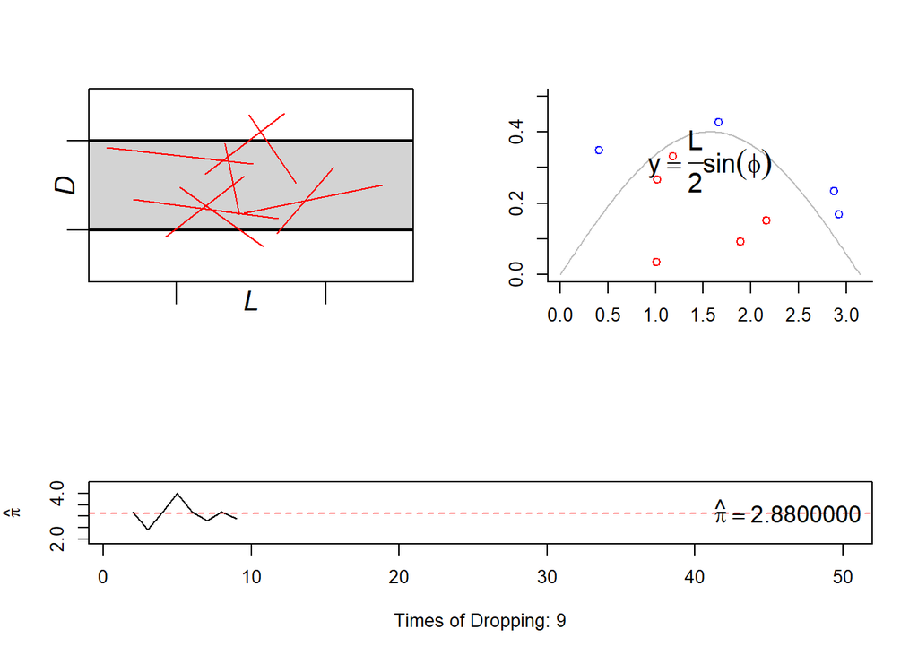

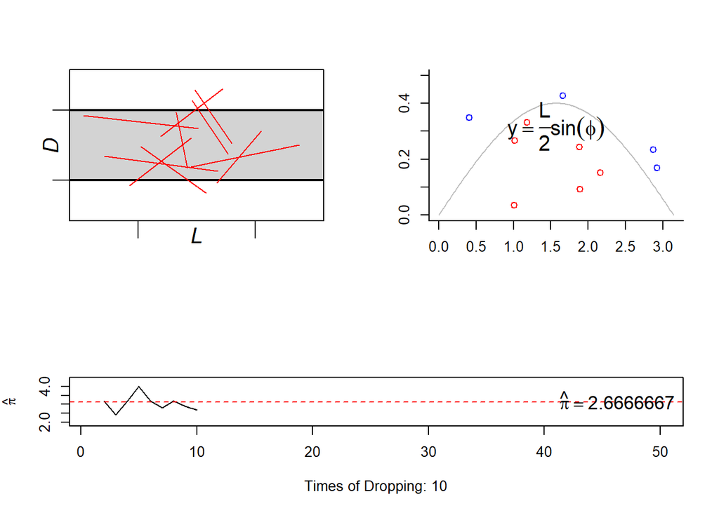

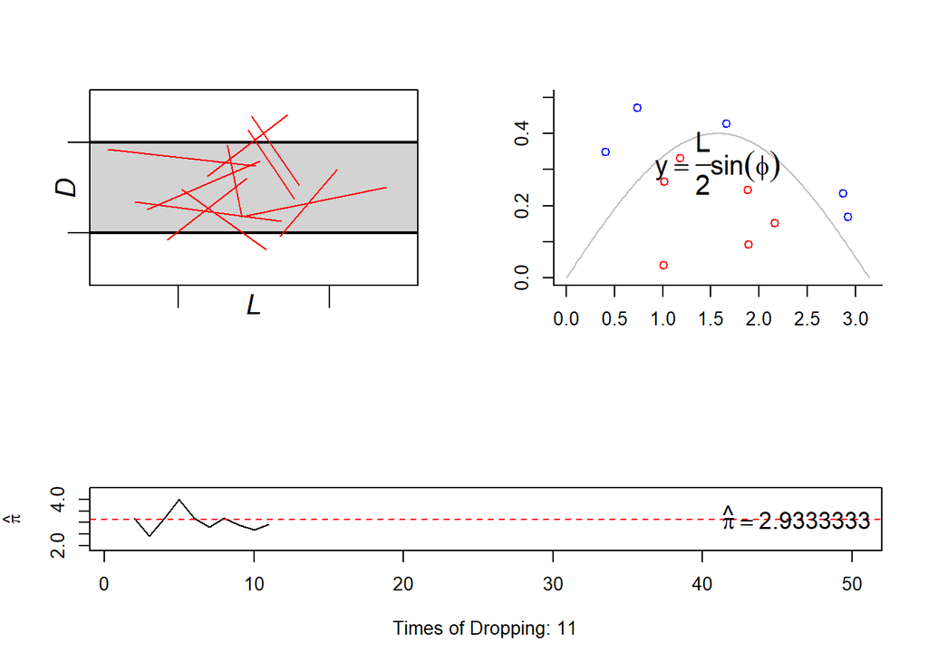

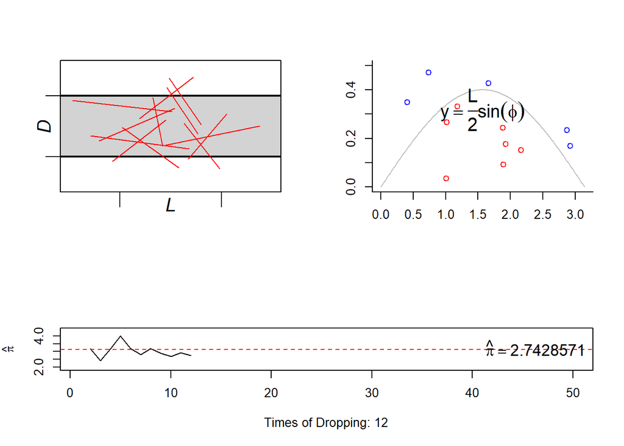

[38 more figures not shown]

```r
install.packages("animation", repos = "https://cloud.r-project.org")
library(animation)

# 布丰投针实验，用于估算圆周率π的值。通过统计针与平行线相交的概率来估算π值。当投针次数足够多时，概率会收敛到 (2 × 针长) / (线距 × π)
buffon.needle(nmax = 500, interval = 0)
```

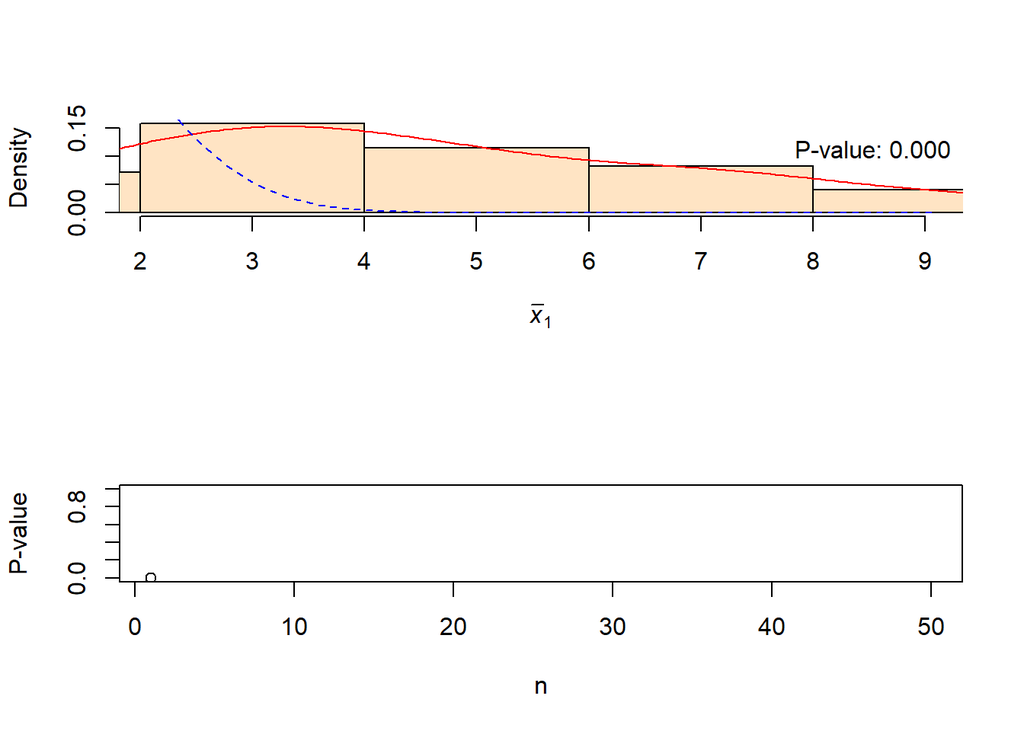

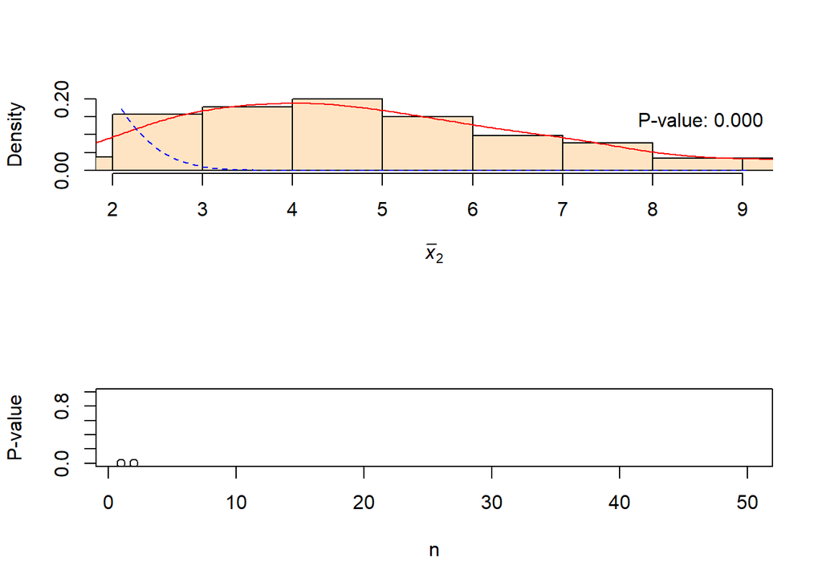

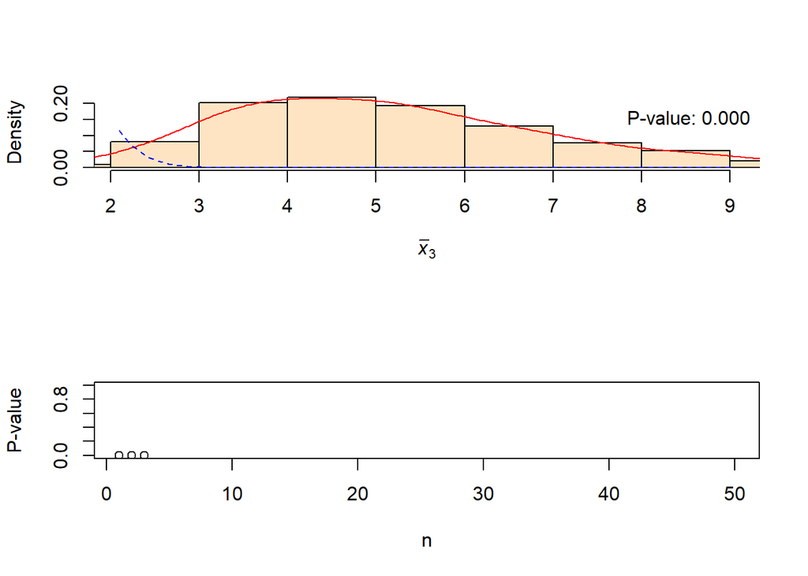

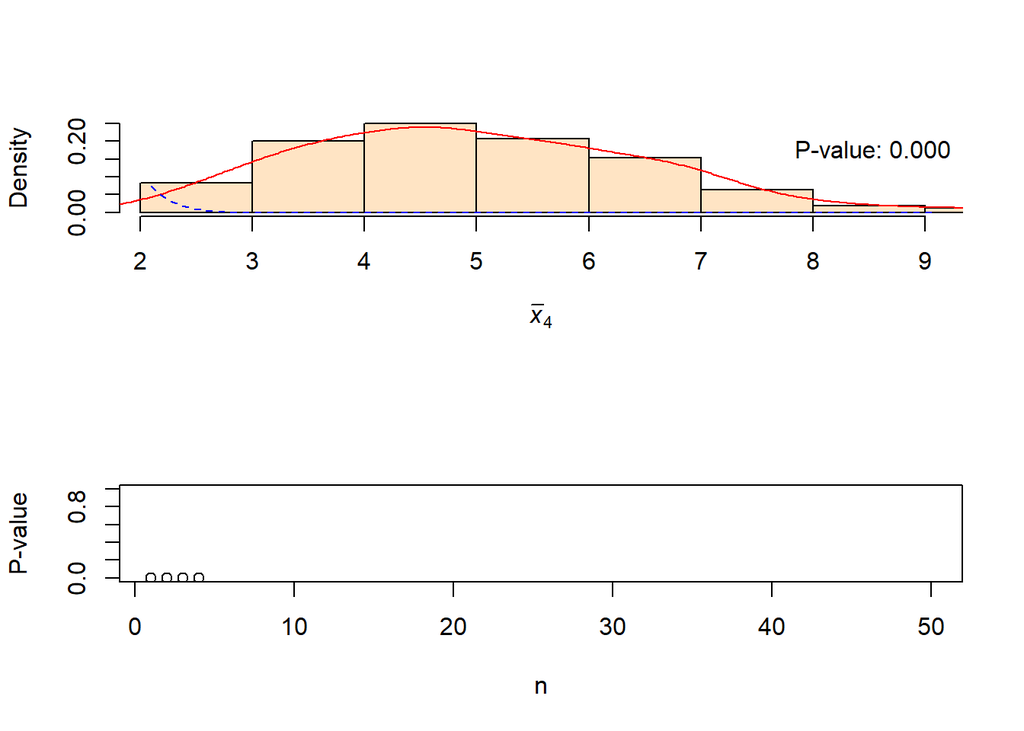

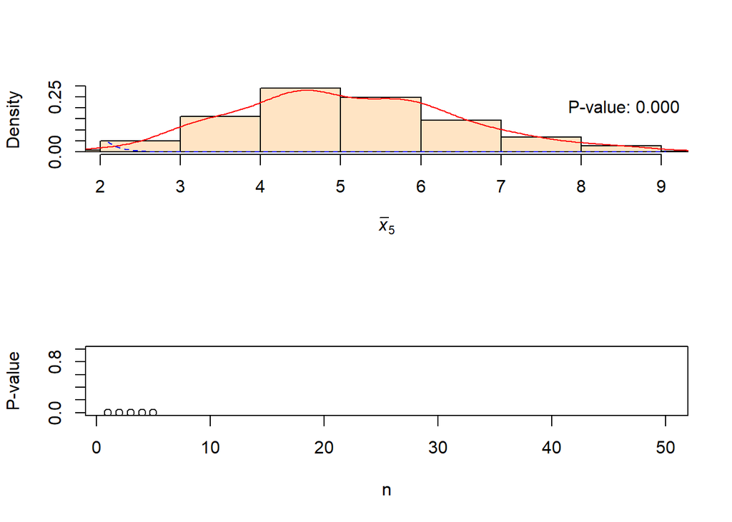

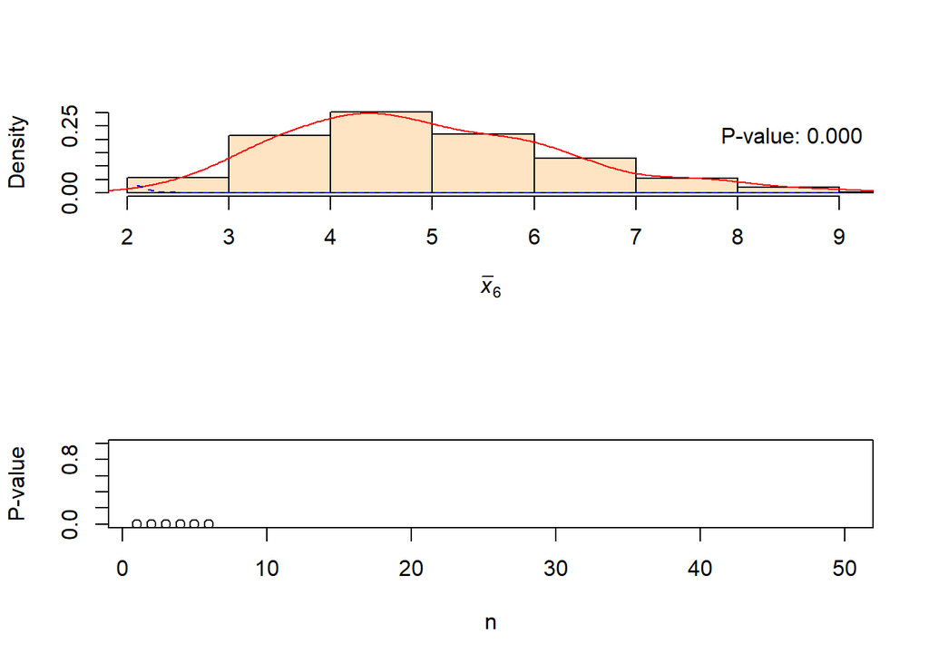

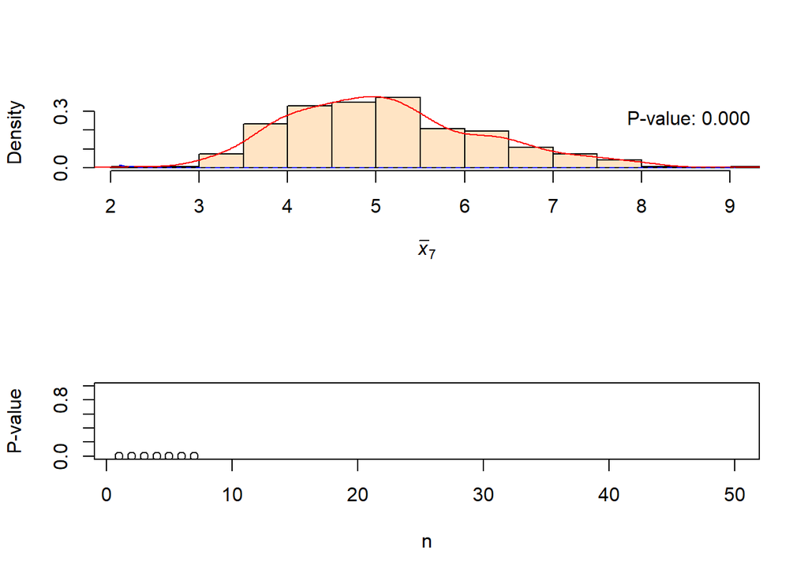

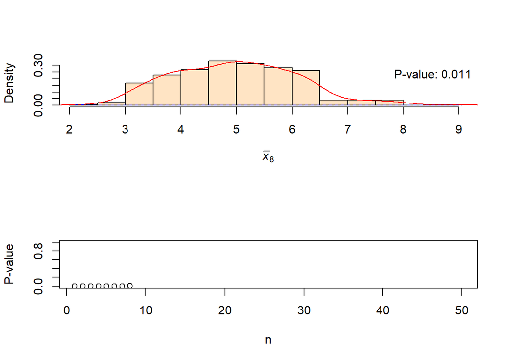

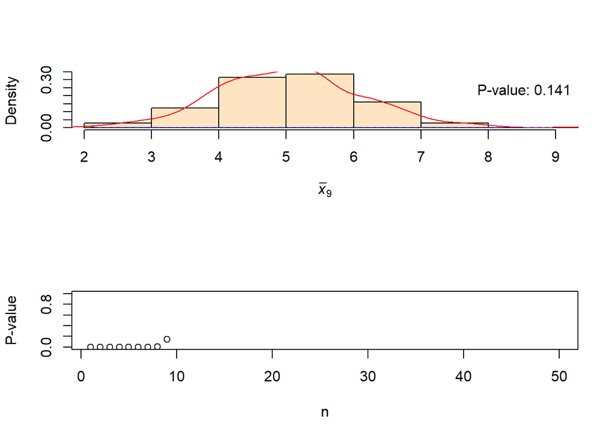

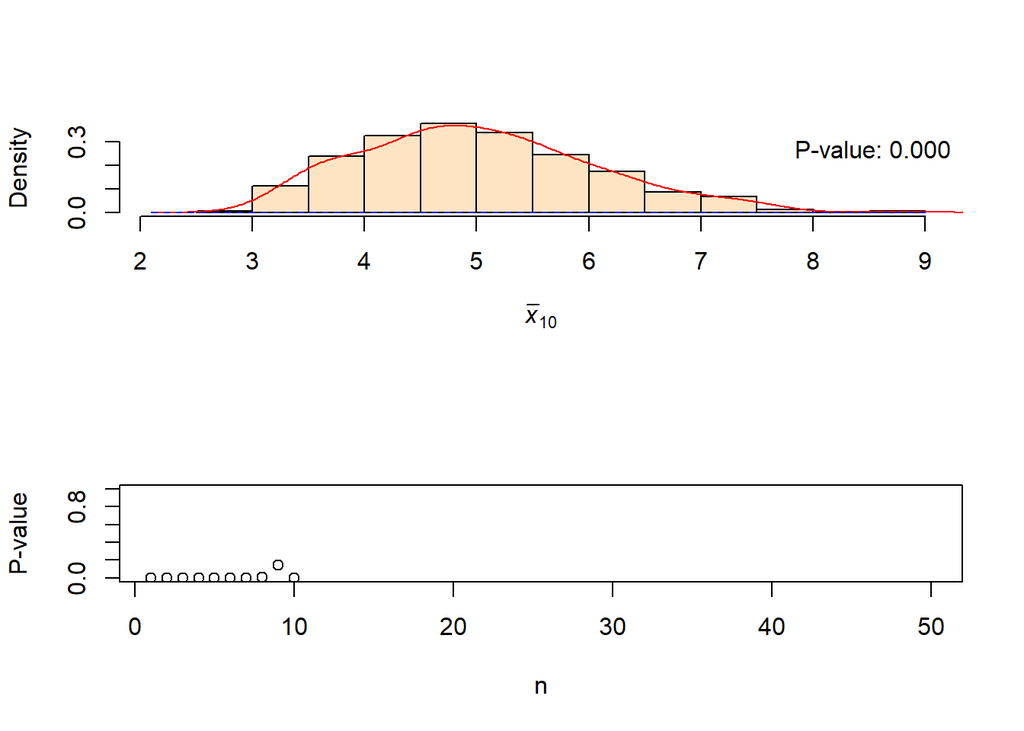

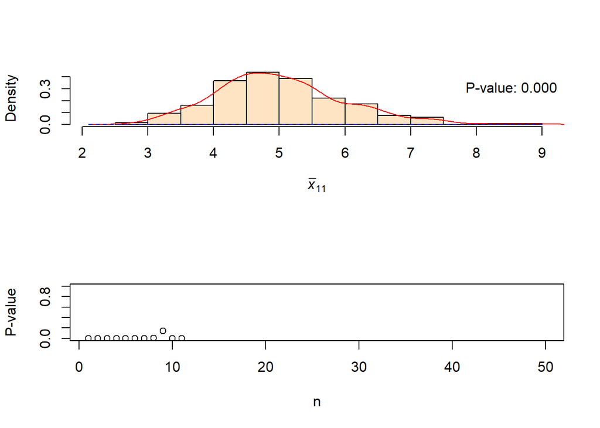

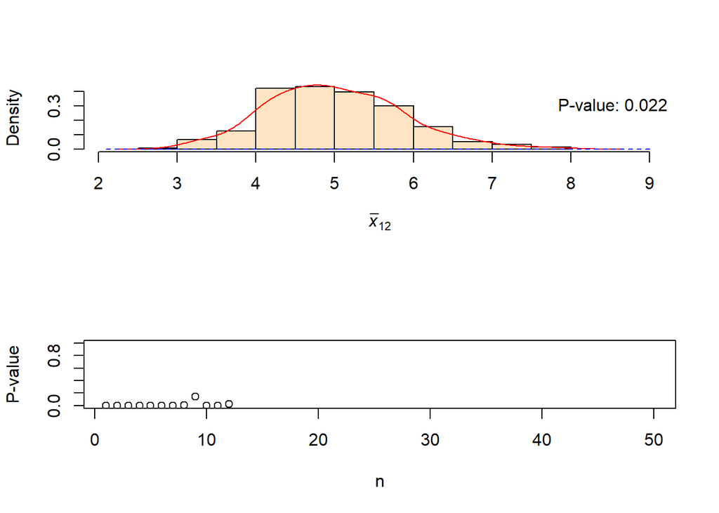

[38 more figures not shown]

```r
# 中心极限定理(CLT)，即使原始数据不服从正态分布，样本均值的抽样分布也会趋近于正态分布
f <- function(n) rchisq(n, 5)
clt.ani(FUN = f)
```

## 2.矩阵操作

将1,2,…,20构成两个4*5阶的矩阵，其中矩阵A是按列输入，矩阵B是按行输入，并作如下运算

```r
# 创建矩阵A（按列输入）
A <- matrix(1:20, nrow = 4, ncol = 5, byrow = FALSE)
cat("矩阵A（按列输入）：\n")
```

```
## 矩阵A（按列输入）：
```

```r
print(A)
```

```
##      [,1] [,2] [,3] [,4] [,5]
## [1,]    1    5    9   13   17
## [2,]    2    6   10   14   18
## [3,]    3    7   11   15   19
## [4,]    4    8   12   16   20
```

```r
# 创建矩阵B（按行输入）
B <- matrix(1:20, nrow = 4, ncol = 5, byrow = TRUE)
cat("\n矩阵B（按行输入）：\n")
```

```
##
## 矩阵B（按行输入）：
```

```r
print(B)
```

```
##      [,1] [,2] [,3] [,4] [,5]
## [1,]    1    2    3    4    5
## [2,]    6    7    8    9   10
## [3,]   11   12   13   14   15
## [4,]   16   17   18   19   20
```

```r
# (1) C = A + B
C <- A + B
cat("(1) C = A + B：\n")
```

```
## (1) C = A + B：
```

```r
print(C)
```

```
##      [,1] [,2] [,3] [,4] [,5]
## [1,]    2    7   12   17   22
## [2,]    8   13   18   23   28
## [3,]   14   19   24   29   34
## [4,]   20   25   30   35   40
```

（2）

$$D = A^T B$$

```r
# (2) D = A^T B
D <- t(A) %*% B
cat("(2) D = A^T B：\n")
```

```
## (2) D = A^T B：
```

```r
print(D)
```

```
##      [,1] [,2] [,3] [,4] [,5]
## [1,]  110  120  130  140  150
## [2,]  246  272  298  324  350
## [3,]  382  424  466  508  550
## [4,]  518  576  634  692  750
## [5,]  654  728  802  876  950
```

（3）
$$E = (e_{ij})_{n \times n} \quad
\text{其中} \quad e_{ij} = a_{ij} \cdot b_{ij}$$

```r
# (3) E = (e_ij) 其中 e_ij = a_ij * b_ij
E <- A * B
cat("(3) E = A * B（逐元素相乘）：\n")
```

```
## (3) E = A * B（逐元素相乘）：
```

```r
print(E)
```

```
##      [,1] [,2] [,3] [,4] [,5]
## [1,]    1   10   27   52   85
## [2,]   12   42   80  126  180
## [3,]   33   84  143  210  285
## [4,]   64  136  216  304  400
```

（4）F是由A的前3行和前3列构成矩阵

```r
# (4) F由A的前3行和前3列构成
F_matrix <- A[1:3, 1:3]
cat("(4) F（A的前3行前3列）：\n")
```

```
## (4) F（A的前3行前3列）：
```

```r
print(F_matrix)
```

```
##      [,1] [,2] [,3]
## [1,]    1    5    9
## [2,]    2    6   10
## [3,]    3    7   11
```

（5）G是由矩阵B的各列构成的矩阵，但不含B的第3列

```r
# (5) G由B的各列构成，但不含第3列
G <- B[, -3]
cat("(5) G（B不含第3列）：\n")
```

```
## (5) G（B不含第3列）：
```

```r
print(G)
```

```
##      [,1] [,2] [,3] [,4]
## [1,]    1    2    4    5
## [2,]    6    7    9   10
## [3,]   11   12   14   15
## [4,]   16   17   19   20
```

## 3.向量操作

（1）构造一个向量x，向量是由5个1，3个2，4个3和2个4构成，注意用到rep()函数

```r
# (1) 构造向量x
x <- rep(1:4, times = c(5, 3, 4, 2))
cat("向量x:\n")
```

```
## 向量x:
```

```r
print(x)
```

```
##  [1] 1 1 1 1 1 2 2 2 3 3 3 3 4 4
```

3.（2）重复向量c(-1,3,-5,7,-9)两次，而且每个元素重复10次，并保存结果。同时，按照从小到大的顺序显示结果

```r
# (2) 重复向量操作
vec <- c(-1, 3, -5, 7, -9)
result <- rep(rep(vec, each = 10), times = 2)
sorted_result <- sort(result)
cat("\n重复后的向量:\n")
```

```
##
## 重复后的向量:
```

```r
print(result)
```

```
##   [1] -1 -1 -1 -1 -1 -1 -1 -1 -1 -1  3  3  3  3  3  3  3  3  3  3 -5 -5 -5 -5 -5
##  [26] -5 -5 -5 -5 -5  7  7  7  7  7  7  7  7  7  7 -9 -9 -9 -9 -9 -9 -9 -9 -9 -9
##  [51] -1 -1 -1 -1 -1 -1 -1 -1 -1 -1  3  3  3  3  3  3  3  3  3  3 -5 -5 -5 -5 -5
##  [76] -5 -5 -5 -5 -5  7  7  7  7  7  7  7  7  7  7 -9 -9 -9 -9 -9 -9 -9 -9 -9 -9
```

```r
cat("\n排序后的向量:\n")
```

```
##
## 排序后的向量:
```

```r
print(sorted_result)
```

```
##   [1] -9 -9 -9 -9 -9 -9 -9 -9 -9 -9 -9 -9 -9 -9 -9 -9 -9 -9 -9 -9 -5 -5 -5 -5 -5
##  [26] -5 -5 -5 -5 -5 -5 -5 -5 -5 -5 -5 -5 -5 -5 -5 -1 -1 -1 -1 -1 -1 -1 -1 -1 -1
##  [51] -1 -1 -1 -1 -1 -1 -1 -1 -1 -1  3  3  3  3  3  3  3  3  3  3  3  3  3  3  3
##  [76]  3  3  3  3  3  7  7  7  7  7  7  7  7  7  7  7  7  7  7  7  7  7  7  7  7
```

## 4.数据框读取

已知有5名学生的数据，如下表所示，用数据框的形式读入数据

| 序号 | 姓名 | 性别 | 年龄 | 身高（cm） | 体重（kg） |
| --- | --- | --- | --- | --- | --- |
| 1 | 张三 | 女 | 14 | 156 | 42.0 |
| 2 | 李四 | 男 | 15 | 165 | 49 |
| 3 | 王五 | 女 | 16 | 157 | 41.5 |
| 4 | 赵六 | 男 | 14 | 162 | 52 |
| 5 | 丁一 | 女 | 15 | 159 | 45.5 |

```r
# 创建学生数据框
students <- data.frame(
  序号 = 1:5,
  姓名 = c("张三", "李四", "王五", "赵六", "丁一"),
  性别 = c("女", "男", "女", "男", "女"),
  年龄 = c(14, 15, 16, 14, 15),
  身高 = c(156, 165, 157, 162, 159),
  体重 = c(42.0, 49, 41.5, 52, 45.5)
)

cat("学生数据:\n")
```

```
## 学生数据:
```

```r
print(students)
```

```
##   序号 姓名 性别 年龄 身高 体重
## 1    1 张三   女   14  156 42.0
## 2    2 李四   男   15  165 49.0
## 3    3 王五   女   16  157 41.5
## 4    4 赵六   男   14  162 52.0
## 5    5 丁一   女   15  159 45.5
```

## 5. 文件读写操作

将4题中的数据表写成一个纯文本文件，用函数read.table()读该文件，然后再用函数write.csv()写成一个能用Excel表能打开的文件，并用Excel表打开

```r
# 写入文本文件
write.table(students, "students.txt", row.names = FALSE)

# 读取文本文件
students_read <- read.table("students.txt", header = TRUE)
print(students_read)
```

```
##   序号 姓名 性别 年龄 身高 体重
## 1    1 张三   女   14  156 42.0
## 2    2 李四   男   15  165 49.0
## 3    3 王五   女   16  157 41.5
## 4    4 赵六   男   14  162 52.0
## 5    5 丁一   女   15  159 45.5
```

```r
# 写入CSV文件
write.csv(students_read, "students.csv", row.names = FALSE)

cat("文件操作完成！已生成students.txt和students.csv文件\n")
```

```
## 文件操作完成！已生成students.txt和students.csv文件
```

```r
# 用Excel打开CSV文件
shell.exec("students.csv")
```

## 6. 儿童数据分析

我们想要分析一组儿童样本的特征。这些来自法国东南部波尔多市的儿童在他们进入到幼儿园的第一年（1996-1997）经历了一次医学检查。下表列出了10个3~4岁的儿童样本数据观测数据。

* 性别（Gender）：女孩（G）、男孩（B）；

* 他们的学校是否位于一个贫困地区（ZEP）：是（Y）、否（N）；

* 年龄，以年（Years）和月（Months）来计量（两个变量：一个表示年，一个表示月）；

* 体重（Weight），单位为kg，四舍五入精确到100g；

* 身高（Height），单位为cm，四舍五入精确到0.5cm.

| 姓名 | Edward | Cynthia | Eugene | Elizabeth | Patrick | John | Albert | Lawrence | Joseph | Leo |
| --- | --- | --- | --- | --- | --- | --- | --- | --- | --- | --- |
| Gender | G | G | B | G | B | B | B | B | B | B |
| Zep | Y | Y | Y | Y | N | Y | N | Y | Y | Y |
| Weight | 16 | 14 | 13.5 | 15.4 | 16.5 | 16 | 17 | 14.8 | 17 | 16.8 |
| Years | 3 | 3 | 3 | 4 | 3 | 4 | 3 | 3 | 4 | 3 |
| Months | 5 | 10 | 5 | 0 | 8 | 0 | 11 | 9 | 1 | 3 |
| Height | 100 | 97 | 95.5 | 101 | 100 | 98.5 | 103 | 98 | 101.5 | 100 |

在R中尝试完成下列操作：

1） 选择适当的数据结构保存上述数据

```r
# 1) 创建数据结构
children_data <- data.frame(
  Name = c("Edward", "Cynthia", "Eugene", "Elizabeth", "Patrick",
           "John", "Albert", "Lawrence", "Joseph", "Leo"),
  Gender = c("G", "G", "B", "G", "B", "B", "B", "B", "B", "B"),
  Zep = c("Y", "Y", "Y", "Y", "N", "Y", "N", "Y", "Y", "Y"),
  Weight = c(16, 14, 13.5, 15.4, 16.5, 16, 17, 14.8, 17, 16.8),
  Years = c(3, 3, 3, 4, 3, 4, 3, 3, 4, 3),
  Months = c(5, 10, 5, 0, 8, 0, 11, 9, 1, 3),
  Height = c(100, 97, 95.5, 101, 100, 98.5, 103, 98, 101.5, 100)
)

cat("儿童数据:\n")
```

```
## 儿童数据:
```

```r
print(children_data)
```

```
##         Name Gender Zep Weight Years Months Height
## 1     Edward      G   Y   16.0     3      5  100.0
## 2    Cynthia      G   Y   14.0     3     10   97.0
## 3     Eugene      B   Y   13.5     3      5   95.5
## 4  Elizabeth      G   Y   15.4     4      0  101.0
## 5    Patrick      B   N   16.5     3      8  100.0
## 6       John      B   Y   16.0     4      0   98.5
## 7     Albert      B   N   17.0     3     11  103.0
## 8   Lawrence      B   Y   14.8     3      9   98.0
## 9     Joseph      B   Y   17.0     4      1  101.5
## 10       Leo      B   Y   16.8     3      3  100.0
```

2） 计算各个变量（Weight、Height）的均值

```r
# 2) 计算均值
cat("\n体重均值:", mean(children_data$Weight))
```

```
##
## 体重均值: 15.7
```

```r
cat("\n身高均值:", mean(children_data$Height))
```

```
##
## 身高均值: 99.45
```

3）计算每个儿童的体重指数（BMI），再把所得到的体重指数结果保存在BMI的变量中

```r
# 3) 计算BMI (体重kg / (身高m)^2)
children_data$BMI <- children_data$Weight / ((children_data$Height/100)^2)
cat("\nBMI计算结果:\n")
```

```
##
## BMI计算结果:
```

```r
print(children_data$BMI)
```

```
##  [1] 16.00000 14.87937 14.80223 15.09656 16.50000 16.49102 16.02413 15.41025
##  [9] 16.50125 16.80000
```

4）将Weight视为Height的一个函数来绘制一个散点图，添加一个标题（至少使用两种不同方法）

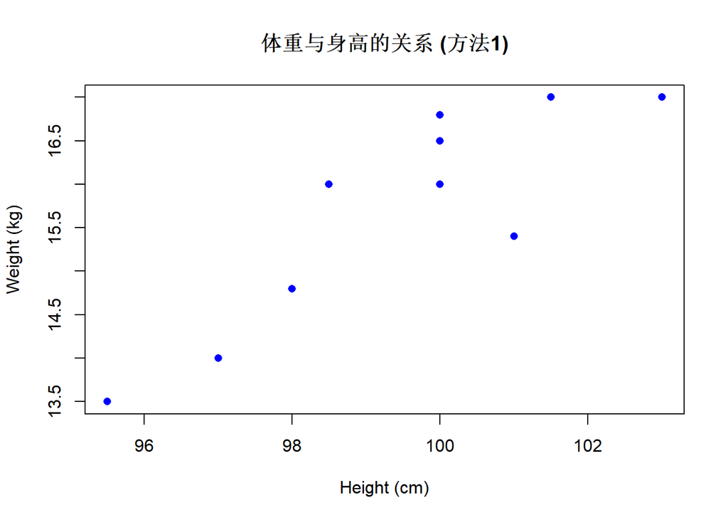

```r
# 4) 绘制散点图
# 方法1: 基础绘图
plot(children_data$Height, children_data$Weight,
     xlab = "Height (cm)", ylab = "Weight (kg)",
     main = "体重与身高的关系 (方法1)",
     pch = 16, col = "blue")
```

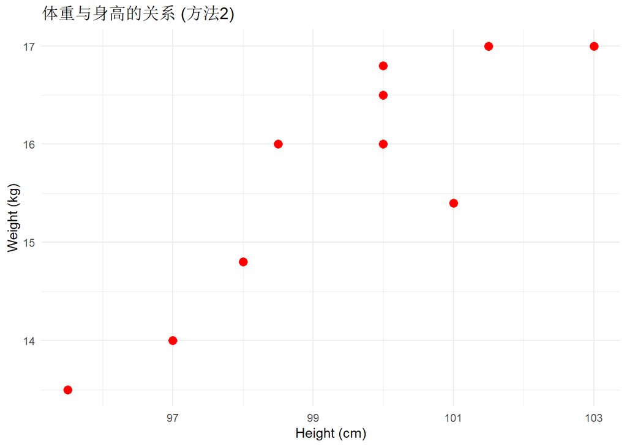

```r
# 方法2: ggplot2
library(ggplot2)
ggplot(children_data, aes(x = Height, y = Weight)) +
  geom_point(color = "red", size = 3) +
  labs(title = "体重与身高的关系 (方法2)",
       x = "Height (cm)", y = "Weight (kg)") +
  theme_minimal()
```

## 7. 数据框操作

在R工作空间中，依据下表创建并存储数据框，并命名为“dframe”：

| Person | Sex | Funny |
| --- | --- | --- |
| Stan | M | High |
| Francine | F | Med |
| Steve | M | Low |
| Roger | M | High |
| Haylay | F | Med |
| Klaus | M | Med |

其中“Pearson”是字符串向量；

“Sex”是水平为F和M的因子向量；

“Funny”也是一个因子向量，其水平为Low、Med和High（给出必要的R实现代码）

```r
# 创建数据框
dframe <- data.frame(
  Person = c("Stan", "Francine", "Steve", "Roger", "Haylay", "Klaus"),
  Sex = factor(c("M", "F", "M", "M", "F", "M"), levels = c("F", "M")),
  Funny = factor(c("High", "Med", "Low", "High", "Med", "Med"),
                 levels = c("Low", "Med", "High"))
)

cat("原始数据框:\n")
```

```
## 原始数据框:
```

```r
print(dframe)
```

```
##     Person Sex Funny
## 1     Stan   M  High
## 2 Francine   F   Med
## 3    Steve   M   Low
## 4    Roger   M  High
## 5   Haylay   F   Med
## 6    Klaus   M   Med
```

（1）Stan 和Francine 都是41岁，Steve是15岁，Hayley 是21岁，Klaus是60岁。Roger的年龄特别大——1600岁。根据这些信息给dframe增加一个新变量Age

```r
# (1) 添加Age变量
dframe$Age <- c(41, 41, 15, 1600, 21, 60)
cat("\n添加Age后的数据框:\n")
```

```
##
## 添加Age后的数据框:
```

```r
print(dframe)
```

```
##     Person Sex Funny  Age
## 1     Stan   M  High   41
## 2 Francine   F   Med   41
## 3    Steve   M   Low   15
## 4    Roger   M  High 1600
## 5   Haylay   F   Med   21
## 6    Klaus   M   Med   60
```

（2）对数据框dframe的列重新排列，使其第一列为Person，第二列为Age，第三列为Sex，第四列为Funny

```r
# (2) 重新排列列顺序
dframe <- dframe[, c("Person", "Age", "Sex", "Funny")]
cat("\n重新排列后的数据框:\n")
```

```
##
## 重新排列后的数据框:
```

```r
print(dframe)
```

```
##     Person  Age Sex Funny
## 1     Stan   41   M  High
## 2 Francine   41   F   Med
## 3    Steve   15   M   Low
## 4    Roger 1600   M  High
## 5   Haylay   21   F   Med
## 6    Klaus   60   M   Med
```

（3） 用一行代码来提取dframe中幽默程度为Med或High的所有女性的名字和年龄

```r
# (3) 提取幽默程度为Med或High的所有女性的名字和年龄
result_3 <- dframe[dframe$Sex == "F" & (dframe$Funny == "Med" | dframe$Funny == "High"),
                   c("Person", "Age")]
cat("\n幽默程度为Med或High的所有女性的名字和年龄:\n")
```

```
##
## 幽默程度为Med或High的所有女性的名字和年龄:
```

```r
print(result_3)
```

```
##     Person Age
## 2 Francine  41
## 5   Haylay  21
```

（4）利用R中处理字符串的方法，提取dframe中名字以S开头的所有个体记录。（提示：substr适用于含多个字符串的向量。）

```r
# (4) 提取名字以S开头的所有个体记录
result_4 <- dframe[substr(dframe$Person, 1, 1) == "S", ]
cat("\n名字以S开头的个体:\n")
```

```
##
## 名字以S开头的个体:
```

```r
print(result_4)
```

```
##   Person Age Sex Funny
## 1   Stan  41   M  High
## 3  Steve  15   M   Low
```

## 8. 函数定义

定义 $h(x,n) = 1 + x + x^2 + \cdots + x^n = \sum_{i=0}^{n} x^i$，利用for循环编制函数$h(x,n)$，计算$h(0.3,55)$

```r
# 定义函数h(x,n)
h <- function(x, n) {
  sum_result <- 0
  for (i in 0:n) {
    sum_result <- sum_result + x^i
  }
  return(sum_result)
}

# 计算h(0.3,55)
result_h <- h(0.3, 55)
cat("h(0.3,55) =", result_h, "\n")
```

```
## h(0.3,55) = 1.428571
```

## 9. 钻石数据分析

R包ggplot2中数据集“diamonds” 包含54000颗钻石的价格及其其它属性

```r
# 加载ggplot2包和数据
library(ggplot2)
data(diamonds)

cat("钻石数据前几行:\n")
```

```
## 钻石数据前几行:
```

```r
print(head(diamonds))
```

```
## # A tibble: 6 × 10
##   carat cut       color clarity depth table price     x     y     z
##   <dbl> <ord>     <ord> <ord>   <dbl> <dbl> <int> <dbl> <dbl> <dbl>
## 1  0.23 Ideal     E     SI2      61.5    55   326  3.95  3.98  2.43
## 2  0.21 Premium   E     SI1      59.8    61   326  3.89  3.84  2.31
## 3  0.23 Good      E     VS1      56.9    65   327  4.05  4.07  2.31
## 4  0.29 Premium   I     VS2      62.4    58   334  4.2   4.23  2.63
## 5  0.31 Good      J     SI2      63.3    58   335  4.34  4.35  2.75
## 6  0.24 Very Good J     VVS2     62.8    57   336  3.94  3.96  2.48
```

（1）绘制价格“price”和重量“carat”的散点图

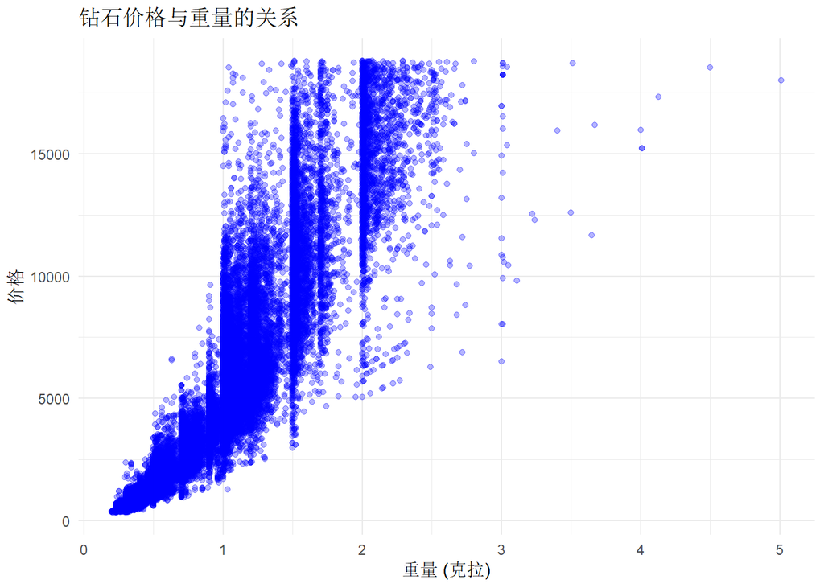

```r
# (1) 价格和重量的散点图
ggplot(diamonds, aes(x = carat, y = price)) +
  geom_point(alpha = 0.3, color = "blue") +
  labs(title = "钻石价格与重量的关系",
       x = "重量 (克拉)", y = "价格") +
  theme_minimal()
```

（2）分面绘制不同颜色“color”钻石价格“price”和重量“carat”的散点图

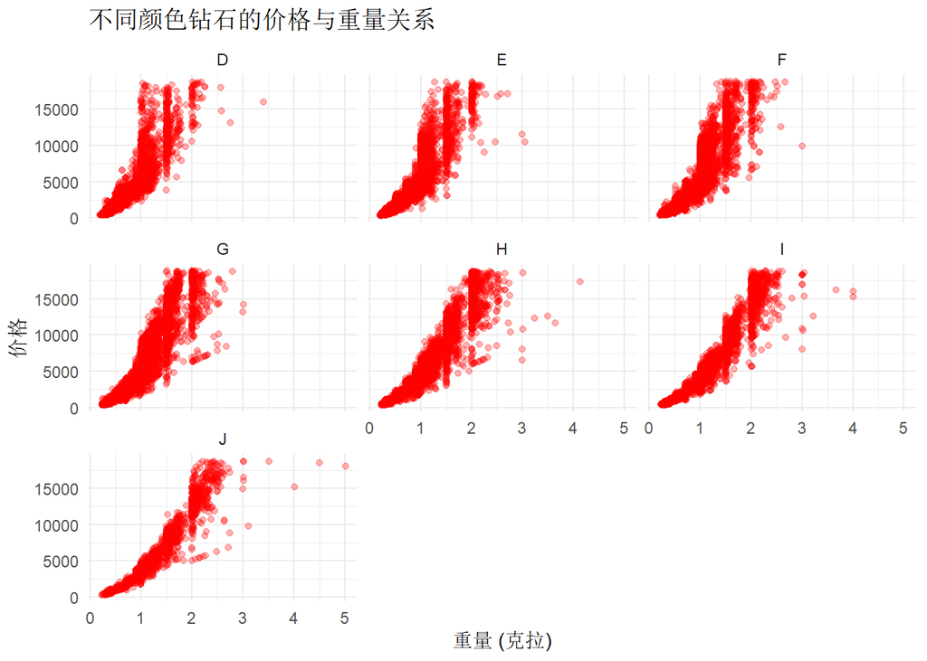

```r
# (2) 分面绘制不同颜色钻石的散点图
ggplot(diamonds, aes(x = carat, y = price)) +
  geom_point(alpha = 0.3, color = "red") +
  facet_wrap(~ color) +
  labs(title = "不同颜色钻石的价格与重量关系",
       x = "重量 (克拉)", y = "价格") +
  theme_minimal()
```

## 10. 杨辉三角函数

杨辉三角，是二项式系数在三角形中的一种几何排列。杨辉三角是中国古代数学的杰出研究成果之一，它把二项式系数图形化，把组合数内在的一些代数性质直观地从图形中体现出来，是一种离散型的数与形的结合。假定我们采用列表结构来存储杨辉三角的系数，即杨辉三角的第n行元素，作为列表的第n个元素。例如一个四层的杨辉三角

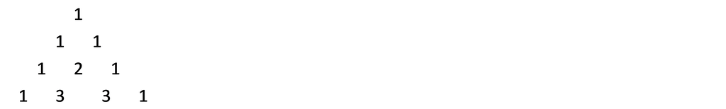

可以表示成 List (c(1),c(1,1),c(1,2,1),c(1,3,3,1)) 。 根据杨辉三角的系数规律，写出生成n层杨辉三角系数列表的函数

```r
# 生成杨辉三角的函数
generate_pascal_triangle <- function(n) {
  if (n <= 0) return(list())

  triangle <- list(c(1))

  for (i in 2:n) {
    prev_row <- triangle[[i-1]]
    new_row <- c(1)  # 每行以1开始

    # 计算中间的值
    for (j in 2:i) {
      if (j <= length(prev_row)) {
        new_row <- c(new_row, prev_row[j-1] + prev_row[j])
      } else {
        new_row <- c(new_row, 1)  # 每行以1结束
      }
    }

    triangle[[i]] <- new_row
  }

  return(triangle)
}

# 测试函数
pascal_4 <- generate_pascal_triangle(4)
cat("4层杨辉三角:\n")
```

```
## 4层杨辉三角:
```

```r
print(pascal_4)
```

```
## [[1]]
## [1] 1
##
## [[2]]
## [1] 1 1
##
## [[3]]
## [1] 1 2 1
##
## [[4]]
## [1] 1 3 3 1
```

```r
pascal_6 <- generate_pascal_triangle(6)
cat("\n6层杨辉三角:\n")
```

```
##
## 6层杨辉三角:
```

```r
print(pascal_6)
```

```
## [[1]]
## [1] 1
##
## [[2]]
## [1] 1 1
##
## [[3]]
## [1] 1 2 1
##
## [[4]]
## [1] 1 3 3 1
##
## [[5]]
## [1] 1 4 6 4 1
##
## [[6]]
## [1]  1  5 10 10  5  1
```

```r
# 可视化杨辉三角
print_pascal_triangle <- function(triangle) {
  for (i in 1:length(triangle)) {
    spaces <- paste(rep(" ", length(triangle) - i), collapse = "")
    row <- paste(triangle[[i]], collapse = " ")
    cat(spaces, row, "\n")
  }
}

cat("\n4层杨辉三角的可视化:\n")
```

```
##
## 4层杨辉三角的可视化:
```

```r
print_pascal_triangle(pascal_4)
```

```
##     1
##    1 1
##   1 2 1
##  1 3 3 1
```